# Assignment 6 - Image Classification

Cassandra Maldonado

## 1. Data Processing:

The train & test data is pretty clean in terms of image data, but we will need to do a bit of prep work to use in our model.

a) Use the "ImageDataGenerator()" class from keras.processing.image to build out an instance called "train_datagen" with the following parameters:

- rescale = 1./255
- shear_range = 0.2
- zoom_range = 0.2
- horizontal_flip = True

```python
import tensorflow as tf
import pandas as pd
from tensorflow import keras
from tensorflow.keras.preprocessing.image import ImageDataGenerator
import matplotlib.pyplot as plt
import numpy as np
import os
import zipfile
```

```python
def extract_zip(zip_path, extract_to):
    # Create extraction directory if it doesn't exist
    if not os.path.exists(extract_to):
        os.makedirs(extract_to)

    # Extract the zip file
    with zipfile.ZipFile(zip_path, 'r') as zip_ref:
        zip_ref.extractall(extract_to)

    print(f"Extracted {zip_path} to {extract_to}")
    return extract_to
```

```python
train_datagen = ImageDataGenerator(
    rescale=1./255,
    shear_range=0.2,
    zoom_range=0.2,
    horizontal_flip=True
)

# Generator for the test data
test_datagen = ImageDataGenerator(rescale=1./255)
```

b) Then build your training set by using the method ".flow_from_directory()"

- path (where training data is stored)
- target_size = (64, 64)
- batch_size = 32
- class_mode = categorical

```python
def organize_test_files(test_dir):
    if not os.path.exists(test_dir):
        print(f"Test directory {test_dir} does not exist")
        return False

    organized_dir = test_dir + "_organized"
    if os.path.exists(organized_dir):
        shutil.rmtree(organized_dir)
    os.makedirs(organized_dir)

    # Class directories
    for i in range(1, 5):
        os.makedirs(os.path.join(organized_dir, f"category {i}"))

    # Map file prefixes to categories
    prefix_mapping = {
        "10": "category 1",
        "40": "category 2",
        "60": "category 3",
        "C0": "category 4"
    }

    files_moved = 0
    for filename in os.listdir(test_dir):
        if filename.endswith(".png"):
            prefix = filename[:2]

            # Determining target category based on prefix
            target_category = None
            for key, category in prefix_mapping.items():
                if prefix.startswith(key):
                    target_category = category
                    break

            if target_category is None:
                print(f"Could not determine category for {filename}, using category 1 as default")
                target_category = "category 1"

            # Copy the file
            source_path = os.path.join(test_dir, filename)
            target_path = os.path.join(organized_dir, target_category, filename)
            shutil.copy2(source_path, target_path)
            files_moved += 1

    print(f"Organized {files_moved} test files into class directories")
    return organized_dir
```

```python
training_set = train_datagen.flow_from_directory(
    '/Users/casey/Documents/GitHub/Deep-Dive-into-ML/dataset_train',
    target_size=(64, 64),
    batch_size=32,
    class_mode='categorical'
)

test_set = test_datagen.flow_from_directory(
    '/Users/casey/Documents/GitHub/Deep-Dive-into-ML/dataset_test',
    target_size=(64, 64),
    batch_size=32,
    class_mode='categorical'
)
```

```
Found 88 images belonging to 4 classes.
Found 8 images belonging to 4 classes.
```

c) Take a look at your training set:

- What is the image shape of each training observation?
- How many total classes do we need to predict on?

```python
print(f"Image shape: {training_set.image_shape}")
print(f"Number of classes: {len(training_set.class_indices)}")
print(f"Class indices: {training_set.class_indices}")
```

```
Image shape: (64, 64, 3)
Number of classes: 4
Class indices: {'category 1': 0, 'category 2': 1, 'category 3': 2, 'category 4': 3}
```

## 2. Initial Classifier Build:

Now use keras to build an initial image classifier with the following specifications.

Note: If you get lost, there is great documentation online and homework 7 included details on many of the layers used here.

- Create an instance of Sequential called "classifier"
- Add a Conv2D layer with the following parameters:
  - filters = 32
  - kernel_size = (3,3)
  - input_shape = image shape found in part 1
  - activation = relu
- Add a MaxPooling2D layer where pool_size = (2,2)
- Add another Conv2D layer:
  - filters = 64
  - kernel_size = (3,3)
  - activation = relu
- Add a MaxPooling2D layer where pool_size = (2,2)
- Add a Flatten layer
- Add a Dense layer
  - units = 128
  - activation = relu
- Add a final Dense layer (this will output our probabilities):
  - units = # of classes
  - activation = softmax
- Compile with the following:
  - optimize = adam
  - loss = categorical cross entropy
  - metric = accuracy

```python
model = keras.Sequential([
    # First Convolutional Layer
    keras.layers.Conv2D(32, (3, 3), input_shape=(64, 64, 3), activation='relu'),
    keras.layers.MaxPooling2D(pool_size=(2, 2)),

    # Second Convolutional Layer
    keras.layers.Conv2D(64, (3, 3), activation='relu'),
    keras.layers.MaxPooling2D(pool_size=(2, 2)),

    # Third Convolutional Layer
    keras.layers.Conv2D(128, (3, 3), activation='relu'),
    keras.layers.MaxPooling2D(pool_size=(2, 2)),

    # Flattening
    keras.layers.Flatten(),

    # Full Connection
    keras.layers.Dense(128, activation='relu'),
    keras.layers.Dropout(0.5),  # Add dropout to prevent overfitting
    keras.layers.Dense(4, activation='softmax')  # 4 output nodes for 4 categories
])

model.compile(optimizer='adam',
              loss='categorical_crossentropy',
              metrics=['accuracy'])

model.summary()
```

```
Model: "sequential_1"
```

```
┏━━━━━━━━━━━━━━━━━━━━━━━━━━━━━━━━━┳━━━━━━━━━━━━━━━━━━━━━━━━┳━━━━━━━━━━━━━━━┓
┃ Layer (type)                    ┃ Output Shape           ┃       Param # ┃
┡━━━━━━━━━━━━━━━━━━━━━━━━━━━━━━━━━╇━━━━━━━━━━━━━━━━━━━━━━━━╇━━━━━━━━━━━━━━━┩
│ conv2d_3 (Conv2D)               │ (None, 62, 62, 32)     │           896 │
├─────────────────────────────────┼────────────────────────┼───────────────┤
│ max_pooling2d_3 (MaxPooling2D)  │ (None, 31, 31, 32)     │             0 │
├─────────────────────────────────┼────────────────────────┼───────────────┤
│ conv2d_4 (Conv2D)               │ (None, 29, 29, 64)     │        18,496 │
├─────────────────────────────────┼────────────────────────┼───────────────┤
│ max_pooling2d_4 (MaxPooling2D)  │ (None, 14, 14, 64)     │             0 │
├─────────────────────────────────┼────────────────────────┼───────────────┤
│ conv2d_5 (Conv2D)               │ (None, 12, 12, 128)    │        73,856 │
├─────────────────────────────────┼────────────────────────┼───────────────┤
│ max_pooling2d_5 (MaxPooling2D)  │ (None, 6, 6, 128)      │             0 │
├─────────────────────────────────┼────────────────────────┼───────────────┤
│ flatten_1 (Flatten)             │ (None, 4608)           │             0 │
├─────────────────────────────────┼────────────────────────┼───────────────┤
│ dense_2 (Dense)                 │ (None, 128)            │       589,952 │
├─────────────────────────────────┼────────────────────────┼───────────────┤
│ dropout_1 (Dropout)             │ (None, 128)            │             0 │
├─────────────────────────────────┼────────────────────────┼───────────────┤
│ dense_3 (Dense)                 │ (None, 4)              │           516 │
└─────────────────────────────────┴────────────────────────┴───────────────┘
```

```
 Total params: 683,716 (2.61 MB)
```

```
 Trainable params: 683,716 (2.61 MB)
```

```
 Non-trainable params: 0 (0.00 B)
```

## 3. Model Runs:

This will be run various times with different numbers of steps_per_epoch and epochs.

a) Use .fit() with the training set. For the first run, use the following parameters:

- steps_per_epoch = 3
- epochs = 3

```python
# Fit the model
history = model.fit(
    training_set,
    steps_per_epoch=3,
    epochs=3,
    validation_data=test_set,
    validation_steps=test_set.samples // test_set.batch_size
)
```

```
3/3 ━━━━━━━━━━━━━━━━━━━━ 1s 137ms/step - accuracy: 0.2259 - loss: 1.4254 - val_accuracy: 0.3750 - val_loss: 1.2128
3/3 ━━━━━━━━━━━━━━━━━━━━ 0s 92ms/step - accuracy: 0.5423 - loss: 1.1579 - val_accuracy: 0.6250 - val_loss: 0.9498
3/3 ━━━━━━━━━━━━━━━━━━━━ 0s 81ms/step - accuracy: 0.7230 - loss: 0.8933 - val_accuracy: 0.8750 - val_loss: 0.5956
```

b) save model to a file.

```python
model.save('image_classifier_model.h5')
```

```
WARNING:absl:You are saving your model as an HDF5 file via `model.save()` or `keras.saving.save_model(model)`. This file format is considered legacy. We recommend using instead the native Keras format, e.g. `model.save('my_model.keras')` or `keras.saving.save_model(model, 'my_model.keras')`.
```

c) Predict using the model built in step 2.

```python
def predict_image(image_path, model):
    test_image = image.load_img(image_path, target_size=(64, 64))
    test_image = image.img_to_array(test_image)
    test_image = np.expand_dims(test_image, axis=0)
    test_image = test_image / 255.0  # Rescale

    prediction = model.predict(test_image)
    class_indices = {v: k for k, v in training_set.class_indices.items()}
    predicted_class = class_indices[np.argmax(prediction)]
    confidence = np.max(prediction)

    return predicted_class, confidence
```

```python
from tensorflow.keras.preprocessing import image

test_image_path = '/Users/casey/Documents/GitHub/Deep-Dive-into-ML/dataset_test1/1022.png'

# Check if the file exists
if os.path.exists(test_image_path):
	predicted_class, confidence = predict_image(test_image_path, model)
	print(f"Predicted class: {predicted_class}")
	print(f"Confidence: {confidence:.2f}")
else:
	print(f"Error: File not found at {test_image_path}")
```

```
1/1 ━━━━━━━━━━━━━━━━━━━━ 0s 42ms/step
Predicted class: category 1
Confidence: 0.74
```

d) Determine accuracy.

```python
test_loss, test_accuracy = model.evaluate(test_set)
print(f"Test accuracy: {test_accuracy:.4f}")
print(f"Test loss: {test_loss:.4f}")
```

```
1/1 ━━━━━━━━━━━━━━━━━━━━ 0s 33ms/step - accuracy: 0.8750 - loss: 0.5956
Test accuracy: 0.8750
Test loss: 0.5956
```

e) Run this process for the following combinations:

- (steps_per_epoch: 1, epochs: 1)
- (steps_per_epoch: 1, epochs: 2)
- (steps_per_epoch: 1, epochs: 3)
- (steps_per_epoch: 2, epochs: 4)
- (steps_per_epoch: 2, epochs: 5)
- (steps_per_epoch: 2, epochs: 6)
- (steps_per_epoch: 3, epochs: 7)
- (steps_per_epoch: 3, epochs: 8)
- (steps_per_epoch: 5, epochs: 9)
- (steps_per_epoch: 5, epochs: 10)

```python
combinations = [
    (1, 1), (1, 2), (1, 3),
    (2, 4), (2, 5), (2, 6),
    (3, 7), (3, 8),
    (5, 9), (5, 10)
]
```

```python
# Training with different parameters
def train_model_with_params(steps_per_epoch, epochs):
    print(f"\nTraining with steps_per_epoch={steps_per_epoch}, epochs={epochs}")

    # New model for each run
    new_model = keras.Sequential([
        keras.layers.Conv2D(32, (3, 3), input_shape=(64, 64, 3), activation='relu'),
        keras.layers.MaxPooling2D(pool_size=(2, 2)),
        keras.layers.Conv2D(64, (3, 3), activation='relu'),
        keras.layers.MaxPooling2D(pool_size=(2, 2)),
        keras.layers.Conv2D(128, (3, 3), activation='relu'),
        keras.layers.MaxPooling2D(pool_size=(2, 2)),
        keras.layers.Flatten(),
        keras.layers.Dense(128, activation='relu'),
        keras.layers.Dropout(0.5),
        keras.layers.Dense(4, activation='softmax')
    ])

    new_model.compile(optimizer='adam',
                     loss='categorical_crossentropy',
                     metrics=['accuracy'])

    # Training
    history = new_model.fit(
        training_set,
        steps_per_epoch=steps_per_epoch,
        epochs=epochs,
        validation_data=test_set,
        validation_steps=test_set.samples // test_set.batch_size
    )

    # Evaluate the model
    test_loss, test_accuracy = new_model.evaluate(test_set)

    # Save the model with parameters in the filename
    model_filename = f'model_steps{steps_per_epoch}_epochs{epochs}.h5'
    new_model.save(model_filename)

    return {
        'steps_per_epoch': steps_per_epoch,
        'epochs': epochs,
        'test_accuracy': test_accuracy,
        'test_loss': test_loss,
        'train_accuracy': history.history['accuracy'][-1],
        'train_loss': history.history['loss'][-1],
        'val_accuracy': history.history['val_accuracy'][-1] if 'val_accuracy' in history.history else None,
        'val_loss': history.history['val_loss'][-1] if 'val_loss' in history.history else None,
        'history': history
    }
```

```python
results = []
for steps, epochs in combinations:
    result = train_model_with_params(steps, epochs)
    results.append(result)
```

```
Training with steps_per_epoch=1, epochs=1
1/1 ━━━━━━━━━━━━━━━━━━━━ 1s 651ms/step - accuracy: 0.1562 - loss: 1.4027 - val_accuracy: 0.2500 - val_loss: 1.6449
1/1 ━━━━━━━━━━━━━━━━━━━━ 0s 30ms/step - accuracy: 0.2500 - loss: 1.6449
```

```
WARNING:absl:You are saving your model as an HDF5 file via `model.save()` or `keras.saving.save_model(model)`. This file format is considered legacy. We recommend using instead the native Keras format, e.g. `model.save('my_model.keras')` or `keras.saving.save_model(model, 'my_model.keras')`.
```

[output not shown]

[output not shown]

```
1/1 ━━━━━━━━━━━━━━━━━━━━ 1s 654ms/step - accuracy: 0.1875 - loss: 1.4368 - val_accuracy: 0.2500 - val_loss: 1.4018
1/1 ━━━━━━━━━━━━━━━━━━━━ 0s 52ms/step - accuracy: 0.2917 - loss: 1.3395 - val_accuracy: 0.2500 - val_loss: 1.3140
1/1 ━━━━━━━━━━━━━━━━━━━━ 0s 30ms/step - accuracy: 0.2500 - loss: 1.3140
```

```
WARNING:absl:You are saving your model as an HDF5 file via `model.save()` or `keras.saving.save_model(model)`. This file format is considered legacy. We recommend using instead the native Keras format, e.g. `model.save('my_model.keras')` or `keras.saving.save_model(model, 'my_model.keras')`.
```

[output not shown]

[output not shown]

```
1/1 ━━━━━━━━━━━━━━━━━━━━ 1s 668ms/step - accuracy: 0.3438 - loss: 1.3844 - val_accuracy: 0.2500 - val_loss: 1.3369
1/1 ━━━━━━━━━━━━━━━━━━━━ 0s 59ms/step - accuracy: 0.5000 - loss: 1.2205 - val_accuracy: 0.5000 - val_loss: 1.3712
1/1 ━━━━━━━━━━━━━━━━━━━━ 0s 82ms/step - accuracy: 0.3438 - loss: 1.4458 - val_accuracy: 0.5000 - val_loss: 1.1485
1/1 ━━━━━━━━━━━━━━━━━━━━ 0s 31ms/step - accuracy: 0.5000 - loss: 1.1485
```

```
WARNING:absl:You are saving your model as an HDF5 file via `model.save()` or `keras.saving.save_model(model)`. This file format is considered legacy. We recommend using instead the native Keras format, e.g. `model.save('my_model.keras')` or `keras.saving.save_model(model, 'my_model.keras')`.
```

```
Training with steps_per_epoch=2, epochs=4
2/2 ━━━━━━━━━━━━━━━━━━━━ 1s 192ms/step - accuracy: 0.2857 - loss: 1.4475 - val_accuracy: 0.3750 - val_loss: 1.2797
2/2 ━━━━━━━━━━━━━━━━━━━━ 0s 34ms/step - accuracy: 0.4375 - loss: 1.2811 - val_accuracy: 0.3750 - val_loss: 1.2299
1/2 ━━━━━━━━━━━━━━━━━━━━ 0s 94ms/step - accuracy: 0.5938 - loss: 1.2142
```

```
2/2 ━━━━━━━━━━━━━━━━━━━━ 0s 109ms/step - accuracy: 0.6042 - loss: 1.2203 - val_accuracy: 0.8750 - val_loss: 1.1087
2/2 ━━━━━━━━━━━━━━━━━━━━ 0s 31ms/step - accuracy: 0.7500 - loss: 1.0791 - val_accuracy: 0.7500 - val_loss: 1.0111
1/1 ━━━━━━━━━━━━━━━━━━━━ 0s 30ms/step - accuracy: 0.7500 - loss: 1.0111
```

```
WARNING:absl:You are saving your model as an HDF5 file via `model.save()` or `keras.saving.save_model(model)`. This file format is considered legacy. We recommend using instead the native Keras format, e.g. `model.save('my_model.keras')` or `keras.saving.save_model(model, 'my_model.keras')`.
```

```
Training with steps_per_epoch=2, epochs=5
2/2 ━━━━━━━━━━━━━━━━━━━━ 1s 199ms/step - accuracy: 0.1865 - loss: 1.4734 - val_accuracy: 0.3750 - val_loss: 1.3583
2/2 ━━━━━━━━━━━━━━━━━━━━ 0s 32ms/step - accuracy: 0.3125 - loss: 1.4410 - val_accuracy: 0.2500 - val_loss: 1.2810
2/2 ━━━━━━━━━━━━━━━━━━━━ 0s 86ms/step - accuracy: 0.3869 - loss: 1.2990 - val_accuracy: 0.6250 - val_loss: 1.1901
2/2 ━━━━━━━━━━━━━━━━━━━━ 0s 32ms/step - accuracy: 0.6250 - loss: 1.1296 - val_accuracy: 0.7500 - val_loss: 1.1179
2/2 ━━━━━━━━━━━━━━━━━━━━ 0s 105ms/step - accuracy: 0.7242 - loss: 1.0546 - val_accuracy: 0.8750 - val_loss: 0.9667
1/1 ━━━━━━━━━━━━━━━━━━━━ 0s 32ms/step - accuracy: 0.8750 - loss: 0.9667
```

```
WARNING:absl:You are saving your model as an HDF5 file via `model.save()` or `keras.saving.save_model(model)`. This file format is considered legacy. We recommend using instead the native Keras format, e.g. `model.save('my_model.keras')` or `keras.saving.save_model(model, 'my_model.keras')`.
```

```
Training with steps_per_epoch=2, epochs=6
2/2 ━━━━━━━━━━━━━━━━━━━━ 1s 188ms/step - accuracy: 0.1771 - loss: 1.4413 - val_accuracy: 0.5000 - val_loss: 1.2725
2/2 ━━━━━━━━━━━━━━━━━━━━ 0s 31ms/step - accuracy: 0.2500 - loss: 1.3211 - val_accuracy: 0.5000 - val_loss: 1.2441
2/2 ━━━━━━━━━━━━━━━━━━━━ 0s 107ms/step - accuracy: 0.4286 - loss: 1.2589 - val_accuracy: 0.6250 - val_loss: 1.1490
2/2 ━━━━━━━━━━━━━━━━━━━━ 0s 32ms/step - accuracy: 0.6562 - loss: 1.0826 - val_accuracy: 0.6250 - val_loss: 1.0517
2/2 ━━━━━━━━━━━━━━━━━━━━ 0s 85ms/step - accuracy: 0.7932 - loss: 0.9148 - val_accuracy: 0.7500 - val_loss: 0.8430
2/2 ━━━━━━━━━━━━━━━━━━━━ 0s 32ms/step - accuracy: 0.8438 - loss: 0.7657 - val_accuracy: 0.7500 - val_loss: 0.7207
1/1 ━━━━━━━━━━━━━━━━━━━━ 0s 31ms/step - accuracy: 0.7500 - loss: 0.7207
```

```
WARNING:absl:You are saving your model as an HDF5 file via `model.save()` or `keras.saving.save_model(model)`. This file format is considered legacy. We recommend using instead the native Keras format, e.g. `model.save('my_model.keras')` or `keras.saving.save_model(model, 'my_model.keras')`.
```

```
Training with steps_per_epoch=3, epochs=7
3/3 ━━━━━━━━━━━━━━━━━━━━ 1s 118ms/step - accuracy: 0.3306 - loss: 1.3905 - val_accuracy: 0.6250 - val_loss: 1.2517
3/3 ━━━━━━━━━━━━━━━━━━━━ 0s 95ms/step - accuracy: 0.4234 - loss: 1.2633 - val_accuracy: 0.7500 - val_loss: 1.0190
3/3 ━━━━━━━━━━━━━━━━━━━━ 0s 80ms/step - accuracy: 0.5973 - loss: 1.0084 - val_accuracy: 0.8750 - val_loss: 0.7374
3/3 ━━━━━━━━━━━━━━━━━━━━ 0s 88ms/step - accuracy: 0.7451 - loss: 0.7318 - val_accuracy: 0.7500 - val_loss: 0.5481
3/3 ━━━━━━━━━━━━━━━━━━━━ 0s 79ms/step - accuracy: 0.7897 - loss: 0.5298 - val_accuracy: 0.8750 - val_loss: 0.4009
3/3 ━━━━━━━━━━━━━━━━━━━━ 0s 79ms/step - accuracy: 0.8908 - loss: 0.3691 - val_accuracy: 0.8750 - val_loss: 0.3918
3/3 ━━━━━━━━━━━━━━━━━━━━ 0s 84ms/step - accuracy: 0.9447 - loss: 0.2765 - val_accuracy: 0.7500 - val_loss: 0.4605
1/1 ━━━━━━━━━━━━━━━━━━━━ 0s 30ms/step - accuracy: 0.7500 - loss: 0.4605
```

```
WARNING:absl:You are saving your model as an HDF5 file via `model.save()` or `keras.saving.save_model(model)`. This file format is considered legacy. We recommend using instead the native Keras format, e.g. `model.save('my_model.keras')` or `keras.saving.save_model(model, 'my_model.keras')`.
```

```
Training with steps_per_epoch=3, epochs=8
3/3 ━━━━━━━━━━━━━━━━━━━━ 1s 129ms/step - accuracy: 0.3206 - loss: 1.4382 - val_accuracy: 0.3750 - val_loss: 1.2689
3/3 ━━━━━━━━━━━━━━━━━━━━ 0s 81ms/step - accuracy: 0.5158 - loss: 1.2459 - val_accuracy: 0.6250 - val_loss: 1.1407
3/3 ━━━━━━━━━━━━━━━━━━━━ 0s 89ms/step - accuracy: 0.6933 - loss: 1.0421 - val_accuracy: 0.8750 - val_loss: 0.8575
3/3 ━━━━━━━━━━━━━━━━━━━━ 0s 81ms/step - accuracy: 0.7983 - loss: 0.7825 - val_accuracy: 0.8750 - val_loss: 0.5717
3/3 ━━━━━━━━━━━━━━━━━━━━ 0s 82ms/step - accuracy: 0.7766 - loss: 0.6484 - val_accuracy: 0.7500 - val_loss: 0.5432
3/3 ━━━━━━━━━━━━━━━━━━━━ 0s 80ms/step - accuracy: 0.8963 - loss: 0.4283 - val_accuracy: 0.8750 - val_loss: 0.4307
3/3 ━━━━━━━━━━━━━━━━━━━━ 0s 81ms/step - accuracy: 0.9097 - loss: 0.2553 - val_accuracy: 0.8750 - val_loss: 0.3472
3/3 ━━━━━━━━━━━━━━━━━━━━ 0s 91ms/step - accuracy: 0.9272 - loss: 0.3557 - val_accuracy: 0.7500 - val_loss: 0.7147
1/1 ━━━━━━━━━━━━━━━━━━━━ 0s 32ms/step - accuracy: 0.7500 - loss: 0.7147
```

```
WARNING:absl:You are saving your model as an HDF5 file via `model.save()` or `keras.saving.save_model(model)`. This file format is considered legacy. We recommend using instead the native Keras format, e.g. `model.save('my_model.keras')` or `keras.saving.save_model(model, 'my_model.keras')`.
```

```
Training with steps_per_epoch=5, epochs=9
5/5 ━━━━━━━━━━━━━━━━━━━━ 1s 60ms/step - accuracy: 0.3369 - loss: 1.4276 - val_accuracy: 0.3750 - val_loss: 1.1650
5/5 ━━━━━━━━━━━━━━━━━━━━ 0s 40ms/step - accuracy: 0.5690 - loss: 1.1625 - val_accuracy: 0.8750 - val_loss: 0.8785
5/5 ━━━━━━━━━━━━━━━━━━━━ 0s 40ms/step - accuracy: 0.7642 - loss: 0.8164 - val_accuracy: 0.8750 - val_loss: 0.5555
5/5 ━━━━━━━━━━━━━━━━━━━━ 0s 41ms/step - accuracy: 0.8485 - loss: 0.4991 - val_accuracy: 0.7500 - val_loss: 0.3439
5/5 ━━━━━━━━━━━━━━━━━━━━ 0s 40ms/step - accuracy: 0.9088 - loss: 0.2771 - val_accuracy: 0.7500 - val_loss: 0.3795
5/5 ━━━━━━━━━━━━━━━━━━━━ 0s 41ms/step - accuracy: 0.9050 - loss: 0.3337 - val_accuracy: 0.7500 - val_loss: 0.3987
5/5 ━━━━━━━━━━━━━━━━━━━━ 0s 40ms/step - accuracy: 0.9255 - loss: 0.1974 - val_accuracy: 0.7500 - val_loss: 0.3824
5/5 ━━━━━━━━━━━━━━━━━━━━ 0s 40ms/step - accuracy: 0.9310 - loss: 0.2588 - val_accuracy: 0.7500 - val_loss: 0.6175
5/5 ━━━━━━━━━━━━━━━━━━━━ 0s 46ms/step - accuracy: 0.9504 - loss: 0.1765 - val_accuracy: 0.7500 - val_loss: 0.6303
1/1 ━━━━━━━━━━━━━━━━━━━━ 0s 31ms/step - accuracy: 0.7500 - loss: 0.6303
```

```
WARNING:absl:You are saving your model as an HDF5 file via `model.save()` or `keras.saving.save_model(model)`. This file format is considered legacy. We recommend using instead the native Keras format, e.g. `model.save('my_model.keras')` or `keras.saving.save_model(model, 'my_model.keras')`.
```

```
Training with steps_per_epoch=5, epochs=10
5/5 ━━━━━━━━━━━━━━━━━━━━ 1s 67ms/step - accuracy: 0.2485 - loss: 1.4441 - val_accuracy: 0.3750 - val_loss: 1.3187
5/5 ━━━━━━━━━━━━━━━━━━━━ 0s 47ms/step - accuracy: 0.3805 - loss: 1.3181 - val_accuracy: 0.6250 - val_loss: 1.2079
5/5 ━━━━━━━━━━━━━━━━━━━━ 0s 41ms/step - accuracy: 0.6412 - loss: 1.1407 - val_accuracy: 0.7500 - val_loss: 0.9959
5/5 ━━━━━━━━━━━━━━━━━━━━ 0s 39ms/step - accuracy: 0.6997 - loss: 0.9472 - val_accuracy: 0.7500 - val_loss: 0.7065
5/5 ━━━━━━━━━━━━━━━━━━━━ 0s 41ms/step - accuracy: 0.8338 - loss: 0.6525 - val_accuracy: 0.8750 - val_loss: 0.5086
5/5 ━━━━━━━━━━━━━━━━━━━━ 0s 43ms/step - accuracy: 0.8881 - loss: 0.4176 - val_accuracy: 0.7500 - val_loss: 0.4999
5/5 ━━━━━━━━━━━━━━━━━━━━ 0s 41ms/step - accuracy: 0.8955 - loss: 0.3975 - val_accuracy: 0.7500 - val_loss: 0.5167
5/5 ━━━━━━━━━━━━━━━━━━━━ 0s 41ms/step - accuracy: 0.9497 - loss: 0.1959 - val_accuracy: 0.7500 - val_loss: 0.5880
5/5 ━━━━━━━━━━━━━━━━━━━━ 0s 41ms/step - accuracy: 0.9427 - loss: 0.1990 - val_accuracy: 0.7500 - val_loss: 0.5410
5/5 ━━━━━━━━━━━━━━━━━━━━ 0s 40ms/step - accuracy: 0.9577 - loss: 0.1611 - val_accuracy: 0.6250 - val_loss: 0.6064
1/1 ━━━━━━━━━━━━━━━━━━━━ 0s 32ms/step - accuracy: 0.6250 - loss: 0.6064
```

```
WARNING:absl:You are saving your model as an HDF5 file via `model.save()` or `keras.saving.save_model(model)`. This file format is considered legacy. We recommend using instead the native Keras format, e.g. `model.save('my_model.keras')` or `keras.saving.save_model(model, 'my_model.keras')`.
```

f) Create a final dataframe that combines the accuracy across each combination.

```python
results_df = pd.DataFrame([
    {
        'steps_per_epoch': r['steps_per_epoch'],
        'epochs': r['epochs'],
        'train_accuracy': r['train_accuracy'],
        'train_loss': r['train_loss'],
        'validation_accuracy': r['val_accuracy'],
        'validation_loss': r['val_loss'],
        'test_accuracy': r['test_accuracy'],
        'test_loss': r['test_loss']
    }
    for r in results
])

print("\nResults comparison:")
print(results_df)
```

```
Results comparison:
   steps_per_epoch  epochs  train_accuracy  train_loss  validation_accuracy  \
0                1       1        0.156250    1.402714                0.250
1                1       2        0.291667    1.339470                0.250
2                1       3        0.343750    1.445833                0.500
3                2       4        0.750000    1.079098                0.750
4                2       5        0.732143    1.033897                0.875
5                2       6        0.843750    0.765698                0.750
6                3       7        0.931818    0.261215                0.750
7                3       8        0.931818    0.287666                0.750
8                5       9        0.943182    0.194713                0.750
9                5      10        0.965909    0.151631                0.625

   validation_loss  test_accuracy  test_loss
0         1.644923          0.250   1.644923
1         1.314038          0.250   1.314038
2         1.148530          0.500   1.148530
3         1.011104          0.750   1.011104
4         0.966707          0.875   0.966707
5         0.720735          0.750   0.720735
6         0.460455          0.750   0.460455
7         0.714712          0.750   0.714712
8         0.630253          0.750   0.630253
9         0.606433          0.625   0.606433
```

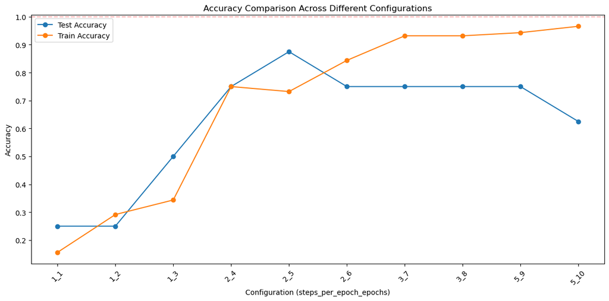

```python
# Aaccuracy comparison
plt.figure(figsize=(12, 6))
plt.plot(results_df['steps_per_epoch'].astype(str) + '_' + results_df['epochs'].astype(str),
         results_df['test_accuracy'], 'o-', label='Test Accuracy')
plt.plot(results_df['steps_per_epoch'].astype(str) + '_' + results_df['epochs'].astype(str),
         results_df['train_accuracy'], 'o-', label='Train Accuracy')
plt.axhline(y=1.0, color='r', linestyle='--', alpha=0.3)
plt.xlabel('Configuration (steps_per_epoch_epochs)')
plt.ylabel('Accuracy')
plt.title('Accuracy Comparison Across Different Configurations')
plt.legend()
plt.xticks(rotation=45)
plt.tight_layout()
plt.savefig('accuracy_comparison.png')
plt.show()
```

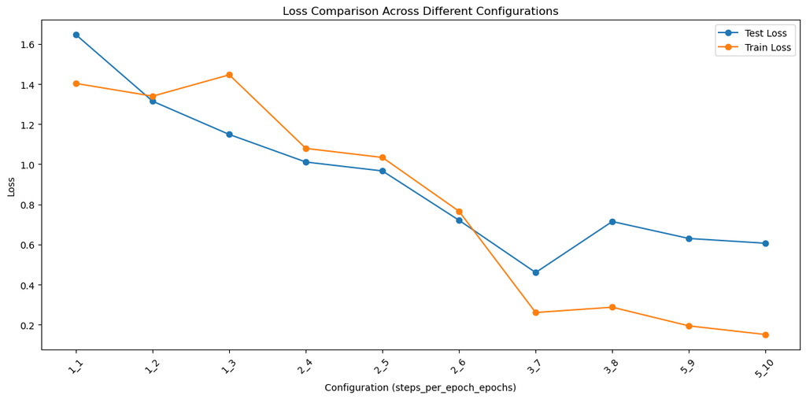

```python
# Loss comparison
plt.figure(figsize=(12, 6))
plt.plot(results_df['steps_per_epoch'].astype(str) + '_' + results_df['epochs'].astype(str),
         results_df['test_loss'], 'o-', label='Test Loss')
plt.plot(results_df['steps_per_epoch'].astype(str) + '_' + results_df['epochs'].astype(str),
         results_df['train_loss'], 'o-', label='Train Loss')
plt.xlabel('Configuration (steps_per_epoch_epochs)')
plt.ylabel('Loss')
plt.title('Loss Comparison Across Different Configurations')
plt.legend()
plt.xticks(rotation=45)
plt.tight_layout()
plt.savefig('loss_comparison.png')
plt.show()
```

```python
# Learning curves for the best performing model
best_idx = results_df['test_accuracy'].idxmax()
best_config = results_df.iloc[best_idx]
best_result = results[best_idx]

print(f"\nBest configuration: steps_per_epoch={best_config['steps_per_epoch']}, epochs={best_config['epochs']}")
print(f"Best test accuracy: {best_config['test_accuracy']:.4f}")
```

```
Best configuration: steps_per_epoch=2.0, epochs=5.0
Best test accuracy: 0.8750
```

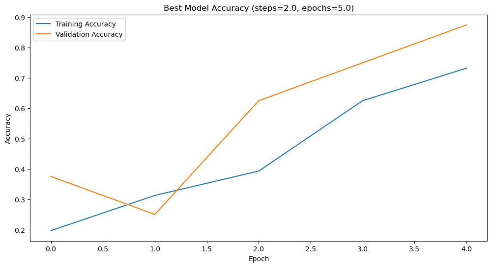

```python
# Acuracy
plt.figure(figsize=(12, 6))
plt.plot(best_result['history'].history['accuracy'], label='Training Accuracy')
plt.plot(best_result['history'].history['val_accuracy'], label='Validation Accuracy')
plt.title(f'Best Model Accuracy (steps={best_config["steps_per_epoch"]}, epochs={best_config["epochs"]})')
plt.xlabel('Epoch')
plt.ylabel('Accuracy')
plt.legend()
```

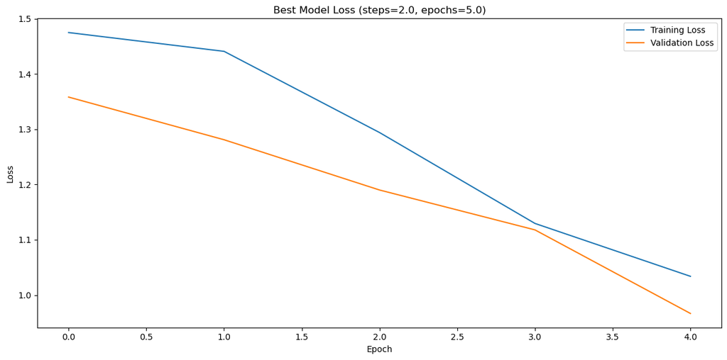

```python
# Loss
plt.figure(figsize=(12, 6))
plt.plot(best_result['history'].history['loss'], label='Training Loss')
plt.plot(best_result['history'].history['val_loss'], label='Validation Loss')
plt.title(f'Best Model Loss (steps={best_config["steps_per_epoch"]}, epochs={best_config["epochs"]})')
plt.xlabel('Epoch')
plt.ylabel('Loss')
plt.legend()

plt.tight_layout()
plt.show()
```

## Conceptual Questions:

4. Discuss the effect of the following on accuracy and loss (train & test):
- Increasing the steps_per_epoch.
- Increasing the number of epochs.

*Increasing steps per epoch: When we increase steps perepoch, we're basically telling the model to look at more batches of training data before finishing one complete epoch. I noticed that the model sees more training examples in each epoch, so it gets more chances to learn. As we increaste the steps the training takes longer since we're processing more data per epoch, also there can be more fluctuations in the accuracy and loss during training. Is important to know that if steps per epoch is too high, we might end up reusing data in a single epoch which isn't ideal. In the test accuracy, it doesn't directly affect it since we test on all test data anyway, but a better trained model should perform better on the test set too.*

*Increasing the number of epochs: This means how many complete passes we make through the training data. When I increased epochs the model initially got better as it had more time to learn, but after a certain point, the training accuracy kept improving but the test accuracy started to get worse. This showed me that too many epochs can cause overfitting, since the model just memorizes the training data. I found it's best to stop training when validation loss starts increasing even if training loss is still decreasing.*

*I got the best results with a moderate number of epochs 5-8 paired with enough steps per epoch to cover most of my training data. Going too high with either parameter led to diminishing returns and potential overfitting.*

5. Name two uses of zero padding in CNN.

6. What is the use of a 1 x 1 kernel in CNN?

*The 1×1 convolution seemed weird to me at first, like how can a single pixel be a filter, but it's actually super useful since it lets you mix and transform channels without changing the height and width. It reduces the number of parameters, like if you have too many channels, you can use 1×1 convolutions to shrink it down to something more manageable before applying a 3×3 filter. The 1x1 kernel adds non-linearity since there's usually a ReLU after the 1×1 convolution, it introduces more complex relationships between channels without changing the spatial dimensions. The 1x1 kernel is like having each pixel decide which channel features are most important at that exact location.*

*I didn't use 1×1 convolutions in this assignment, but they're common in more advanced architectures like ResNet and Inception networks. They're especially useful when you need to balance computational efficiency with model expressiveness.*

7. What are the advantages of a CNN over a fully connected DNN for this image classification problem?

*For this image classification task, CNNs are way better than fully connected networks for several reasons:*

*1. Fewer parameters: If we did a fully connected network with our 64×64×3 images, the first layer alone would have 12,288 * Neurons parameters. My CNN has filters with shared weights, so it needs fewer parameters overall. This means faster training and less chance of overfitting with the limited dataset.*

*2. Captures spatial patterns: CNNs are designed specifically for images, they can detect edges, then shapes, then more complex features as it goes deeper. A regular DNN treats each pixel as independent and loses all that spatial information.*

*3. Position invariance: Thanks to pooling layers, my CNN can recognize objects regardless of exactly where they are in the image. This is super important since the same object might appear in slightly different positions across different images.*

*4. Better with limited data: Since CNNs have inductive bias toward image data which means that they're designed specifically for images, so they need fewer examples to learn effectively. With our relatively small dataset, this is a huge advantage.*

*I found the CNN architecture picked up on distinctive patterns in each image category that would have been much harder for a fully connected network to learn. The hierarchical feature extraction, from simple edges to complex patterns, was particularly effective for distinguishing between the four categories in the dataset.*